# Inspección por muestreo

```python
from google.colab import drive
drive.mount('/content/drive/')
```

```python
import os

path = os.getcwd()
try:
  os.chdir(path + '/drive/My Drive/QC_Kentei')
except:
  pass

os.getcwd()
```

```
'/content/drive/My Drive/QC_Kentei'
```

```python
!pip install japanize-matplotlib
```

```
     ━━━━━━━━━━━━━━━━━━━━━━━━━━━━━━━━━━━━━━━━ 4.1/4.1 MB 11.2 MB/s eta 0:00:00
  Preparing metadata (setup.py) ... done
```

```python
import numpy as np
import matplotlib.pyplot as plt
import japanize_matplotlib
import pandas as pd
```

## 11.1

JIS Z 9002:1956の計数規格型一回抜き取り検査を実施したい。なるべく合格させたいロットの不適合品率の上限を $ p_0 = 1.0% $ として、なるべく不合格とさせたいロットの不適合品率の下限を $ p_1 = 30% $ としたときの抜き取り検査方式：

1. サンプルサイズ $ n $、合格判定個数 $ c $
2. $ p_1 = 30% $ のロットが合格する確率、$ p_0 = 1.0% $ のロットが不合格となる確率

Quiero realizar una inspección por muestreo del tipo de norma de conteo JIS Z 9002:1956. Con el objetivo de aceptar lo más posible lotes con una tasa de defectuosos máxima de $ p_0 = 1.0% $ y de rechazar lo más posible lotes con una tasa de defectuosos mínima del $ p_1 = 30% $, el esquema de inspección por muestro sería:

1. Tamaño de la muestra $ n $, número de aceptaciones $ c $.
2. Probabilidad de que un lote con una tasa de defectuosos de $ p_1 = 30% $, pase la inspección, y la probabilidad de que un lote con una tasa de defectuosos de $ p_0 = 1.0% $ no pase la inspección.

```python
from scipy.stats import binom

# JIS Z 9002:1956 Datos de la tabla de muestro
SAMPLING_TABLE = [
    (5, 0), (7, 0), (10,0), (15, 1), (15,2), (20, 1), (20,3), (25, 4), (30, 6)
]

# Condiciones establecidas
p0 = 0.01  # Límite superior de la tasa de unidades no conformes
           #para los lotes que se desean aceptar
p1 = 0.30  # Límites inferiro de la tasa de unidades no conformes
           # para los lotes que se desean rechazar
alpha = 0.05  # L(p0) >= 1 - alpha
beta = 0.17   # L(p1) <= beta

# Búsqueda de n y c que cumplan las condiciones
def find_sampling_plan_from_table(p0, p1, alpha, beta, table):
    for n, c in table:
        L_p0 = binom.cdf(c, n, p0)  # Probabilidad de aceptación para p0
        L_p1 = binom.cdf(c, n, p1)  # Probabilidad de aceptación para p1

        if L_p0 >= 1 - alpha and L_p1 <= beta:
            return n, c
    return None, None

# Ejecución
n, c = find_sampling_plan_from_table(p0, p1, alpha, beta, SAMPLING_TABLE)

print(f"Tamaño de muestra n: {n}")
print(f"Número de aceptaciones c: {c}")
```

```
Tamaño de muestra n: 5
Número de aceptaciones c: 0
```

```
Probabilidad de que el lote pasa la inspección: 0.17
Probabilidad de que el lote no pase la inspección: 0.05
```

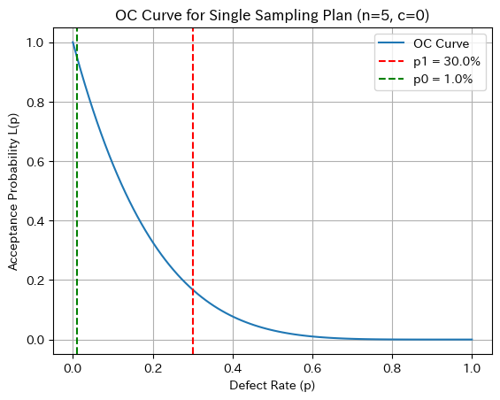

```python
# Rango de tasas de defectuosos
p_values = np.linspace(0, 1, 100)

# Cálculo de la curva OC (probabilidad de que el lote pase la inspección L(p)
L_p = binom.cdf(c, n, p_values)

# Probabilidad de aceptación / rechazo de lotes con una tasa de
# defectuosos de p1=30% y p0=1.0%
p1 = 0.3
p0 = 0.01
prob_p1_accepted = binom.cdf(c, n, p1)
prob_p0_rejected = 1 - binom.cdf(c, n, p0)

# Mostrar los resultados
prob_p1_accepted, prob_p0_rejected

print(f"Probabilidad de que el lote pasa la inspección: {prob_p1_accepted:.2f}")
print(F"Probabilidad de que el lote no pase la inspección: {prob_p0_rejected:.2f}")

# Curva OC
plt.plot(p_values, L_p, label="OC Curve")
plt.axvline(p1, color="r", linestyle="--", label=f"p1 = {p1*100}%")
plt.axvline(p0, color="g", linestyle="--", label=f"p0 = {p0*100}%")
#plt.xlim(0,0.1)
plt.title("OC Curve for Single Sampling Plan (n=5, c=0)")
plt.xlabel("Defect Rate (p)")
plt.ylabel("Acceptance Probability L(p)")
plt.legend()
plt.grid(True)
plt.show()
```

## 11.2

JIS Z 9015-1:2006（計数値検査に対する抜き取り検査手順ー第一部）に基づいて、$ AQL=0.40% $、ロットサイズ $ N=1000 $ 検査水準IIに対する一回抜き取りなみ検査の抜き取り検査方法を求める。

- サンプル文字
- サンプルサイズ $ n $
- 合格半的個数 $ A_c $
- 不合格判定個数 $ R_c $

Se desea determinar el método de muestreo para la inspección por muestreo de aceptación de acuerdo con JIS Z 9015-1:2006 (Procedimientos de inspección por muestreo para inspección por atributos - Parte 1), con los siguientes parámetros:

- Nivel de calidad aceptable (AQL): 0.40%
- Tamaño del lote (N): 1000
- Nivel de inspección II
- Tipo de inspección: Inspección única normal

Determinar los siguientes valores

- Letra de código de muestra
- Tamaño de muestra (n)
- Número de aceptación (Ac)
- Número de rechazo (Rc)

```python
def get_sampling_plan(aql, lot_size, inspection_level="II"):
    # Criterios de muestreo de aceptación basados en JIS Z 9015-1 (ISO 2859-1)
    # Datos de la tabla de especificaciones
    jis_table = pd.DataFrame({
        "Code": ["J", "K", "L"],  # Códiogo
        "Lot Size Range": [(501, 1200), (1201, 3200), (3201, 10000)],
        "Sample Size": [80, 125, 200],
        "AQL 0.40%": [(1, 2), (1, 2), (2, 3)],
    })

    # Obtener la letra de código correspondiente al tamaño del lote
    selected_row = jis_table[(jis_table["Lot Size Range"].apply(lambda x: x[0] <= lot_size <= x[1]))]
    if selected_row.empty:
        raise ValueError("El tamaño del lote está fuera del rango de aplicación")

    sample_size = selected_row["Sample Size"].values[0]
    ac, re = selected_row["AQL 0.40%"].values[0]
    code = selected_row["Code"].values[0]

    return sample_size, ac, re, code

# Configuración de parámetros
aql = 0.40  # Valor de AQL
lot_size = 1000  # Tamaño del lote

# Obtener el plan de muestreo
n, Ac, Re, Code = get_sampling_plan(aql, lot_size)

# Mostrar resultados
print("Codigo: ", Code)
print(f"Tamaño de la muestra: {n}")
print(f"Número de aceptación (Ac): {Ac}")
print(f"Número de rechazo (Re): {Re}")
```

```
Codigo:  J
Tamaño de la muestra: 80
Número de aceptación (Ac): 1
Número de rechazo (Re): 2
```

## 11.3

計量基準型抜き取り検査において、検査に提出されたロットの特性値ｘの母平均 $ \mu $ が、$ \mu_0 $ 以上の時は合格させたい良いロットとし、$ \mu_1 $ 以下の時は不合格としたい悪いロットとし、平均値が大きい方が好ましいとする。また、ｘは正規分布に従い、その標準偏差 $ \sigma $ の値は既知であるとする。そのロットから抜き取った大きさｎのサンプルの平均値 $ \bar{x} $ の値を合格判定値と比較することによって、ロットの合否を判定する抜き取り方式を設計したい。

En la inspección por muestreo con base en criterios de medición, se considera un lote bueno aquel cuya media poblaciónal $ \mu $ de la caracterísitica x es al menos $ \mu_0 $ y un lote malo aquel cuya media poblacional es como máximo $ \mu_1 $. Se asume que un mayor valor de la media es preferible. Además, se supone que x sigue una distribución normal y que el valor de su desviación estándar $ \sigma $ es conocido. Se desea diseñar un plan de muestreo en el cual la aceptación o rechazo del lote se determine comparando la media muestral $ \bar{x} $ de una muestra de tamaño $ n $ con un valor de referencia para la aceptación.

#### 1.

平均値が 100.0以上のロットはできるだけ合格させたいが、平均値が 98.0 以下のロットはできるだけ不合格にしたい。ただし、ロットの標準偏差 $ \sigma = 1.0 $ 、 $ \alpha = 0.05 $、 $ \beta = 0.10 $ とする。

下記を求めよ。

1. サンプル n の大きさ
2. 下限合格判定値

Se desea aceptar en la medida de lo posible los lotes cuya media sea al menos 100.0, mientras que los lotes con una media de 98.0 o menos deben ser rechazados en la medida de lo posible. Se asume que la desviación del es $ \sigma = 1.0 $, con $ \alpha = 0.05 $ y $ \beta = 0.10 $.

Determinar lo siguiente:

- El tamaño de la muestra n
- El valor límite inferior para la aceptación

```python
import math
from scipy.stats import norm

# Configuraci[on de parámetros
mu_0 = 100.0  # Media del lote que se desea aceptar
mu_1 = 98.0   # Media del lote que se desea rechazar
sigma = 1.0   # Desviación estándar
alpha = 0.05  # Probabilidad del riesgo del productor
beta = 0.10   # Probabilidad de riesto del productor

# Cálculo de Kα y Kβ
K_alpha = norm.ppf(1 - alpha)
K_beta = norm.ppf(1 - beta)

# Cálculo del valor límite inferior de aceptación Xbar_L
n_row = ((K_alpha + K_beta) * sigma / (mu_0 - mu_1)) ** 2
Xbar_L = mu_0 - K_alpha * (sigma / math.sqrt(n_row))

# Cálculo del tamaño de la muestra n
n = math.ceil(n_row)  # El tamaño de la muestra se redondea hacia arriba
                      # el entero más cercano

#
print(f"Tamaño de la muestra n: {n}")
print(f"Valor límite inferior de aceptación Xbar_L: {Xbar_L:.2f}")
```

```
Tamaño de la muestra n: 3
Valor límite inferior de aceptación Xbar_L: 98.88
```

```python
notebook_name = 'QCKentei_1-11.ipynb'
notebook_name_html = notebook_name.replace(".ipynb",".html")
print(notebook_name + '  ->  ' + notebook_name_html)

!jupyter nbconvert --to html {notebook_name}
!mv {notebook_name_html} ../html/
```

```
QCKentei_1-11.ipynb  ->  QCKentei_1-11.html
[NbConvertApp] Converting notebook QCKentei_1-11.ipynb to html
[NbConvertApp] WARNING | Alternative text is missing on 2 image(s).
[NbConvertApp] Writing 446386 bytes to QCKentei_1-11.html
```